# Analysis of the effect of reducing working hours

Dain Lee

FEB, 2024

```r
library(SmartEDA)
library(dplyr)
library(MASS)
```

```r
library(readxl)
library(HistData)
library(car)
library(lmtest)
library(wooldridge)
library(ggplot2)
library(gridExtra)
```

# 0. Data Load

```r
ds <- read.csv('C:/Users/dain/Downloads/R/oes2002_2006.csv')
summary(ds)
```

```
##       year           size            male             age
##  Min.   :2002   Min.   :8.000   Min.   :0.0000   Min.   :18.00
##  1st Qu.:2003   1st Qu.:8.000   1st Qu.:1.0000   1st Qu.:33.00
##  Median :2004   Median :9.000   Median :1.0000   Median :38.00
##  Mean   :2004   Mean   :8.511   Mean   :0.8098   Mean   :39.38
##  3rd Qu.:2006   3rd Qu.:9.000   3rd Qu.:1.0000   3rd Qu.:46.00
##  Max.   :2006   Max.   :9.000   Max.   :1.0000   Max.   :84.00
##       edu             edu1              edu2             edu3
##  Min.   : 0.00   Min.   :0.00000   Min.   :0.0000   Min.   :0.0000
##  1st Qu.:12.00   1st Qu.:0.00000   1st Qu.:0.0000   1st Qu.:0.0000
##  Median :14.00   Median :0.00000   Median :0.0000   Median :0.0000
##  Mean   :14.15   Mean   :0.05797   Mean   :0.3472   Mean   :0.1211
##  3rd Qu.:16.00   3rd Qu.:0.00000   3rd Qu.:1.0000   3rd Qu.:0.0000
##  Max.   :21.00   Max.   :1.00000   Max.   :1.0000   Max.   :1.0000
##       edu4             mar             tenure          metro
##  Min.   :0.0000   Min.   :0.0000   Min.   : 0.00   Min.   :0.0000
##  1st Qu.:0.0000   1st Qu.:1.0000   1st Qu.: 3.00   1st Qu.:0.0000
##  Median :0.0000   Median :1.0000   Median : 9.00   Median :1.0000
##  Mean   :0.4347   Mean   :0.7962   Mean   :10.04   Mean   :0.5521
##  3rd Qu.:1.0000   3rd Qu.:1.0000   3rd Qu.:15.00   3rd Qu.:1.0000
##  Max.   :1.0000   Max.   :1.0000   Max.   :50.00   Max.   :1.0000
##       oc1               oc2              oc3               oc4
##  Min.   :0.00000   Min.   :0.0000   Min.   :0.00000   Min.   :0.0000
##  1st Qu.:0.00000   1st Qu.:0.0000   1st Qu.:0.00000   1st Qu.:0.0000
##  Median :0.00000   Median :0.0000   Median :0.00000   Median :0.0000
##  Mean   :0.03028   Mean   :0.4618   Mean   :0.07275   Mean   :0.2781
##  3rd Qu.:0.00000   3rd Qu.:1.0000   3rd Qu.:0.00000   3rd Qu.:1.0000
##  Max.   :1.00000   Max.   :1.0000   Max.   :1.00000   Max.   :1.0000
##       ind1               ind2             ind3              ind4
##  Min.   :0.000000   Min.   :0.0000   Min.   :0.00000   Min.   :0.00000
##  1st Qu.:0.000000   1st Qu.:0.0000   1st Qu.:0.00000   1st Qu.:0.00000
##  Median :0.000000   Median :0.0000   Median :0.00000   Median :0.00000
##  Mean   :0.003662   Mean   :0.4369   Mean   :0.01641   Mean   :0.03561
##  3rd Qu.:0.000000   3rd Qu.:1.0000   3rd Qu.:0.00000   3rd Qu.:0.00000
##  Max.   :1.000000   Max.   :1.0000   Max.   :1.00000   Max.   :1.00000
##       ind5            ind6             ind7            ind8
##  Min.   :0.000   Min.   :0.0000   Min.   :0.000   Min.   :0.000
##  1st Qu.:0.000   1st Qu.:0.0000   1st Qu.:0.000   1st Qu.:0.000
##  Median :0.000   Median :0.0000   Median :0.000   Median :0.000
##  Mean   :0.055   Mean   :0.1184   Mean   :0.119   Mean   :0.215
##  3rd Qu.:0.000   3rd Qu.:0.0000   3rd Qu.:0.000   3rd Qu.:0.000
##  Max.   :1.000   Max.   :1.0000   Max.   :1.000   Max.   :1.000
##   non_regular         weektime        hourlywage     hourly_wage_r
##  Min.   :0.00000   Min.   : 32.00   Min.   : 0.000   Min.   : 0.000
##  1st Qu.:0.00000   1st Qu.: 40.00   1st Qu.: 1.000   1st Qu.: 1.000
##  Median :0.00000   Median : 48.00   Median : 1.000   Median : 1.000
##  Mean   :0.08632   Mean   : 49.89   Mean   : 1.296   Mean   : 1.545
##  3rd Qu.:0.00000   3rd Qu.: 55.00   3rd Qu.: 2.000   3rd Qu.: 2.000
##  Max.   :1.00000   Max.   :140.00   Max.   :40.000   Max.   :52.000
```

# 1. EDA

```r
ExpData(ds, type = 1)
```

```
##                                           Descriptions     Value
## 1                                   Sample size (nrow)     30584
## 2                              No. of variables (ncol)        28
## 3                    No. of numeric/interger variables        28
## 4                              No. of factor variables         0
## 5                                No. of text variables         0
## 6                             No. of logical variables         0
## 7                          No. of identifier variables         0
## 8                                No. of date variables         0
## 9             No. of zero variance variables (uniform)         0
## 10               %. of variables having complete cases 100% (28)
## 11   %. of variables having >0% and <50% missing cases    0% (0)
## 12 %. of variables having >=50% and <90% missing cases    0% (0)
## 13          %. of variables having >=90% missing cases    0% (0)
```

```r
ExpData(ds, type=2)
```

```
##    Index Variable_Name Variable_Type Sample_n Missing_Count Per_of_Missing
## 1      1          year       integer    30584             0              0
## 2      2          size       integer    30584             0              0
## 3      3          male       integer    30584             0              0
## 4      4           age       integer    30584             0              0
## 5      5           edu       integer    30584             0              0
## 6      6          edu1       integer    30584             0              0
## 7      7          edu2       integer    30584             0              0
## 8      8          edu3       integer    30584             0              0
## 9      9          edu4       integer    30584             0              0
## 10    10           mar       integer    30584             0              0
## 11    11        tenure       integer    30584             0              0
## 12    12         metro       integer    30584             0              0
## 13    13           oc1       integer    30584             0              0
## 14    14           oc2       integer    30584             0              0
```

[output cut: 43 more lines]

```r
ExpNumStat(ds)
```

```
##           Vname Group    TN nNeg nZero  nPos NegInf PosInf NA_Value
## 1           age   All 30584    0     0 30584      0      0        0
## 2           edu   All 30584    0    45 30539      0      0        0
## 6 hourly_wage_r   All 30584    0  1967 28617      0      0        0
## 5    hourlywage   All 30584    0  3439 27145      0      0        0
## 3        tenure   All 30584    0  1195 29389      0      0        0
## 4      weektime   All 30584    0     0 30584      0      0        0
##   Per_of_Missing     sum min max   mean median     SD    CV IQR Skewness
## 1              0 1204427  18  84 39.381     38  9.076 0.230  13    0.395
## 2              0  432806   0  21 14.151     14  2.692 0.190   4   -0.334
## 6              0   47248   0  52  1.545      1  1.028 0.666   1    8.096
## 5              0   39632   0  40  1.296      1  0.899 0.693   1    6.746
## 3              0  307175   0  50 10.044      9  7.753 0.772  12    0.764
## 4              0 1525964  32 140 49.894     48 11.823 0.237  15    2.241
##   Kurtosis
## 1   -0.176
## 2    1.199
## 6  304.547
## 5  224.725
## 3   -0.076
## 4    9.064
```

```r
ExpNumStat(ds, by='GA', gp='size')
```

```
##            Vname    Group    TN nNeg nZero  nPos NegInf PosInf NA_Value
## 1            age size:All 30584    0     0 30584      0      0        0
## 7            age   size:8 14969    0     0 14969      0      0        0
## 13           age   size:9 15615    0     0 15615      0      0        0
## 2            edu size:All 30584    0    45 30539      0      0        0
## 8            edu   size:8 14969    0    29 14940      0      0        0
## 14           edu   size:9 15615    0    16 15599      0      0        0
## 6  hourly_wage_r size:All 30584    0  1967 28617      0      0        0
## 12 hourly_wage_r   size:8 14969    0  1318 13651      0      0        0
## 18 hourly_wage_r   size:9 15615    0   649 14966      0      0        0
## 5     hourlywage size:All 30584    0  3439 27145      0      0        0
## 11    hourlywage   size:8 14969    0  2188 12781      0      0        0
## 17    hourlywage   size:9 15615    0  1251 14364      0      0        0
## 3         tenure size:All 30584    0  1195 29389      0      0        0
## 9         tenure   size:8 14969    0   718 14251      0      0        0
```

[output cut: 42 more lines]

```
## $`0`
```

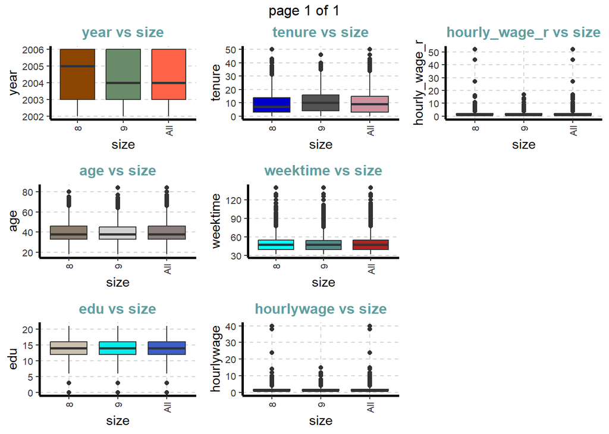

```r
plot <- ds |> ExpNumViz(Page=c(3,3), target = 'size')

plot
```

다른 변수는 거의 동일하게 분포한 반면, size=8에서 임금, 실질임금의 이상치가 더 많이 나타남.

```
## $`0`
```

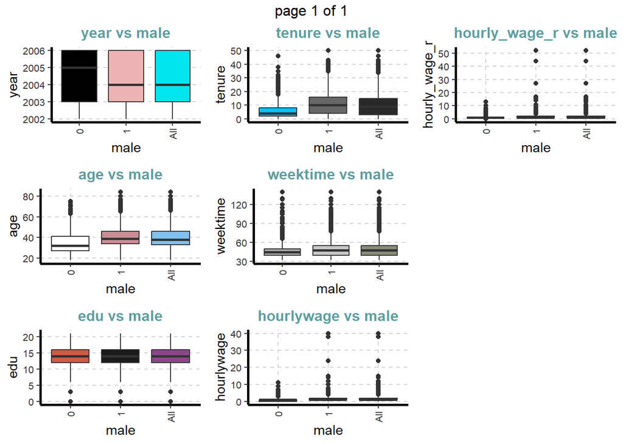

```r
plot <- ds |> ExpNumViz(Page=c(3,3), target = 'male')

plot
```

남성 근로자의 나이가 평균적으로 높고, 정규직 근속연수가 조금 더 긺. 임금, 실질임금의 꼬리가 긺(이상치가 있음)

```
## $`0`
```

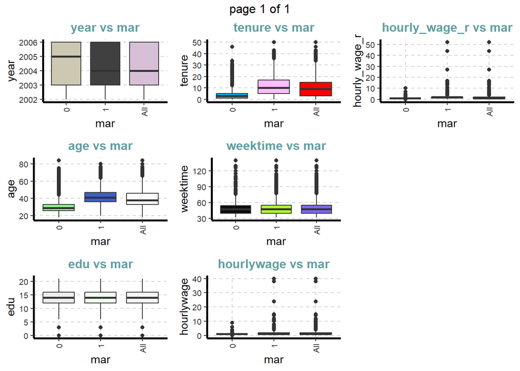

```r
plot <- ds |> ExpNumViz(Page=c(3,3), target = 'mar')

plot
```

당연하게 기혼 근로자의 나이와 근속연수가 평균적으로 더 높고, 임금, 실질임금의 꼬리가 긺

```
## $`0`
```

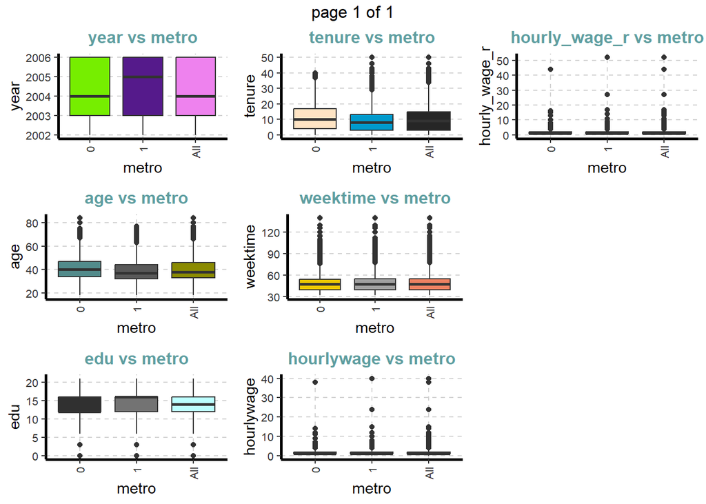

```r
plot <- ds |> ExpNumViz(Page=c(3,3), target = 'metro')

plot
```

```
## $`0`
```

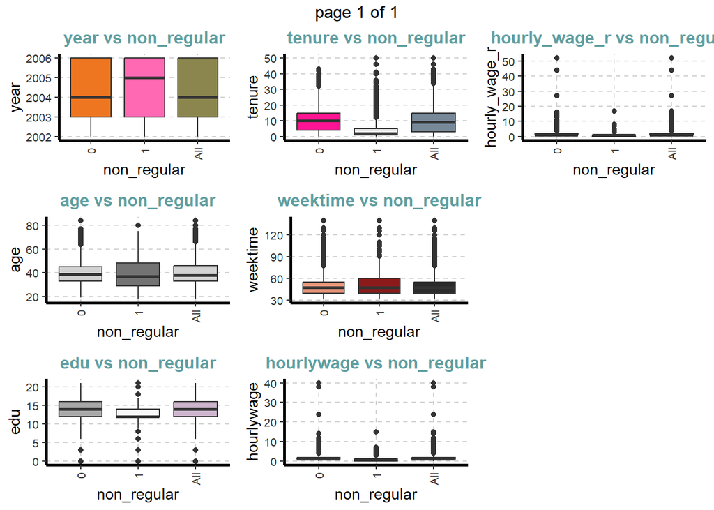

```r
plot <- ds |> ExpNumViz(Page=c(3,3), target = 'non_regular')

plot
```

```r
ExpCTable(ds)
```

```
##       Variable Valid Frequency Percent CumPercent
## 1         year  2002      4831   15.80      15.80
## 2         year  2003      5193   16.98      32.78
## 3         year  2004      5587   18.27      51.05
## 4         year  2005      5446   17.81      68.86
## 5         year  2006      9527   31.15     100.01
## 6         year TOTAL     30584      NA         NA
## 7         size     8     14969   48.94      48.94
## 8         size     9     15615   51.06     100.00
## 9         size TOTAL     30584      NA         NA
## 10        male     0      5818   19.02      19.02
## 11        male     1     24766   80.98     100.00
## 12        male TOTAL     30584      NA         NA
## 13        edu1     0     28811   94.20      94.20
## 14        edu1     1      1773    5.80     100.00
```

[output cut: 55 more lines]

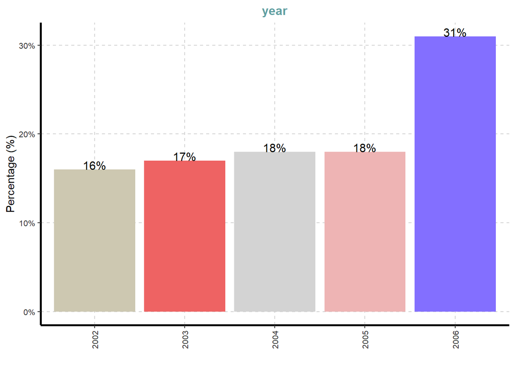

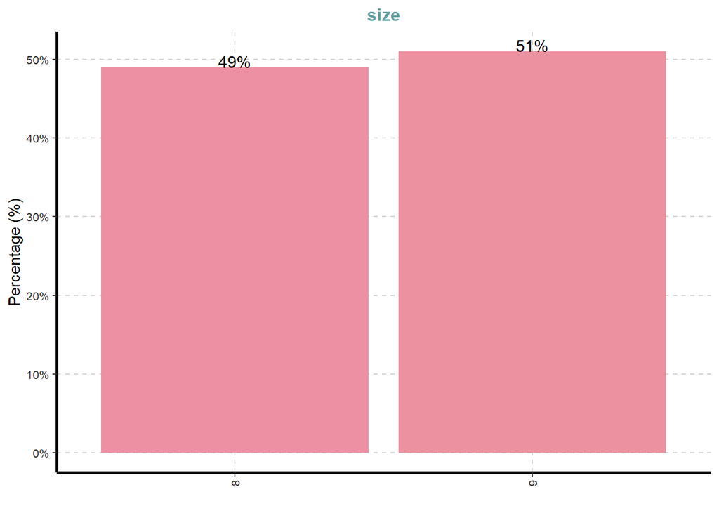

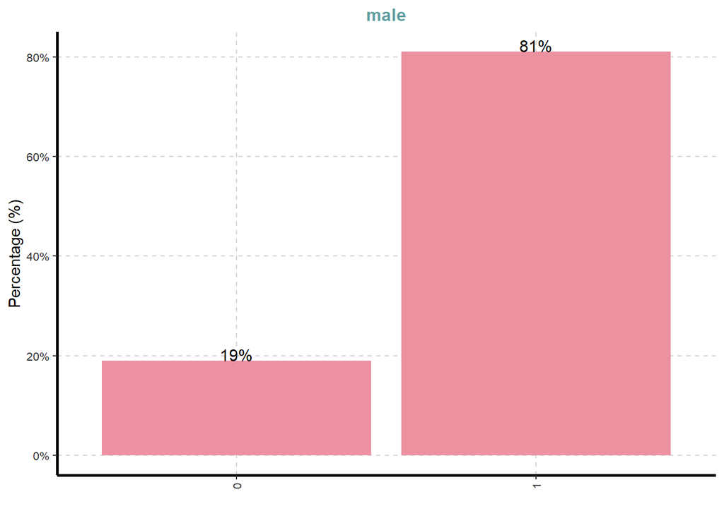

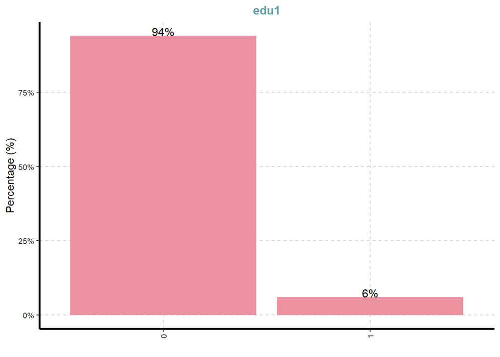

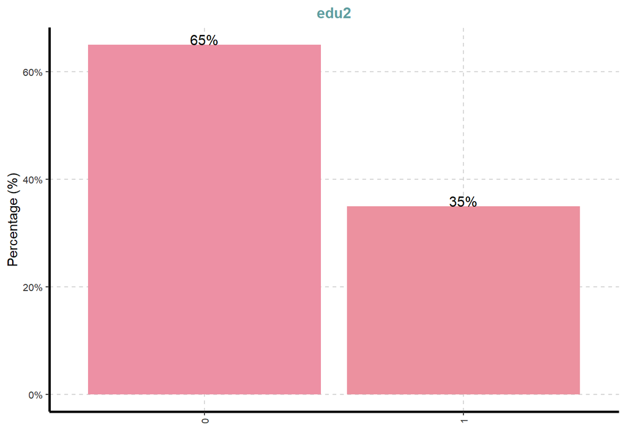

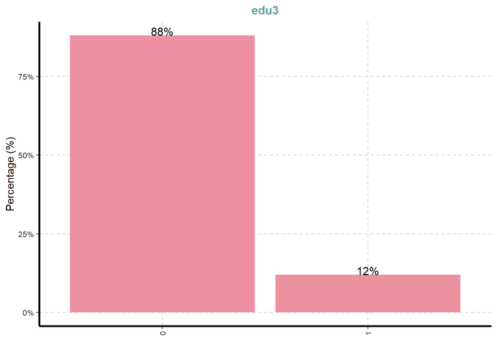

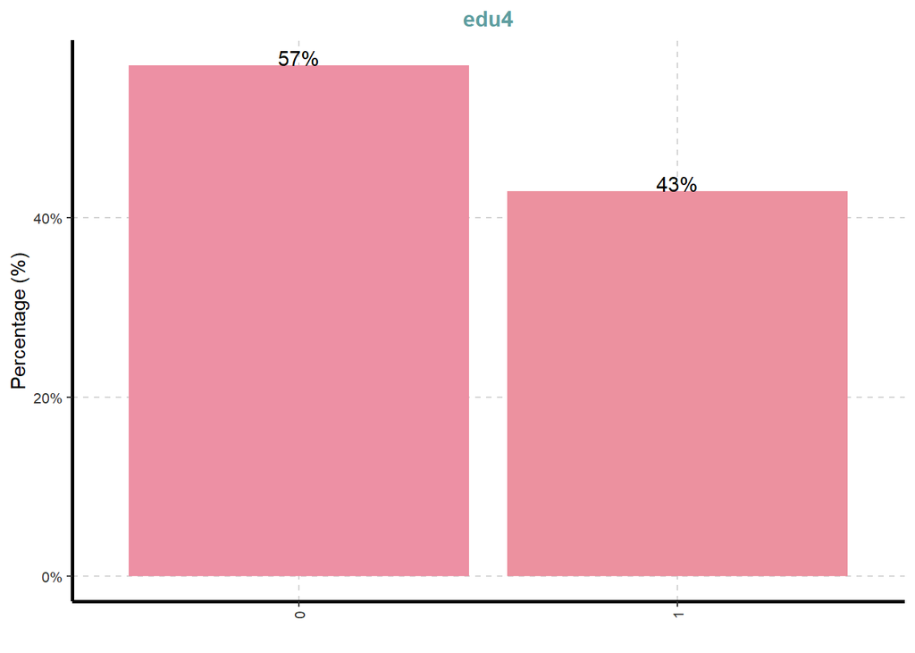

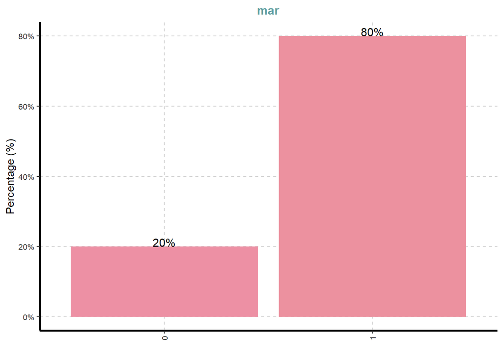

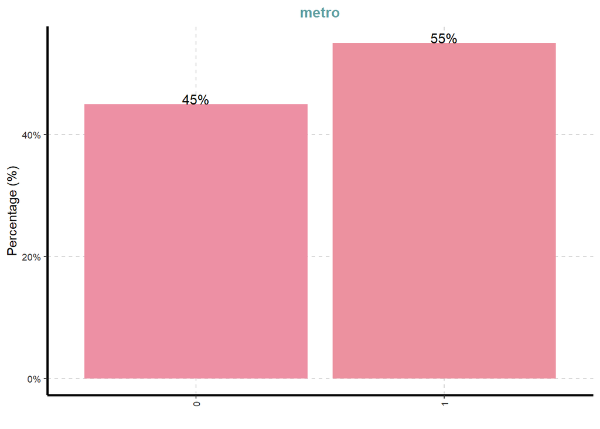

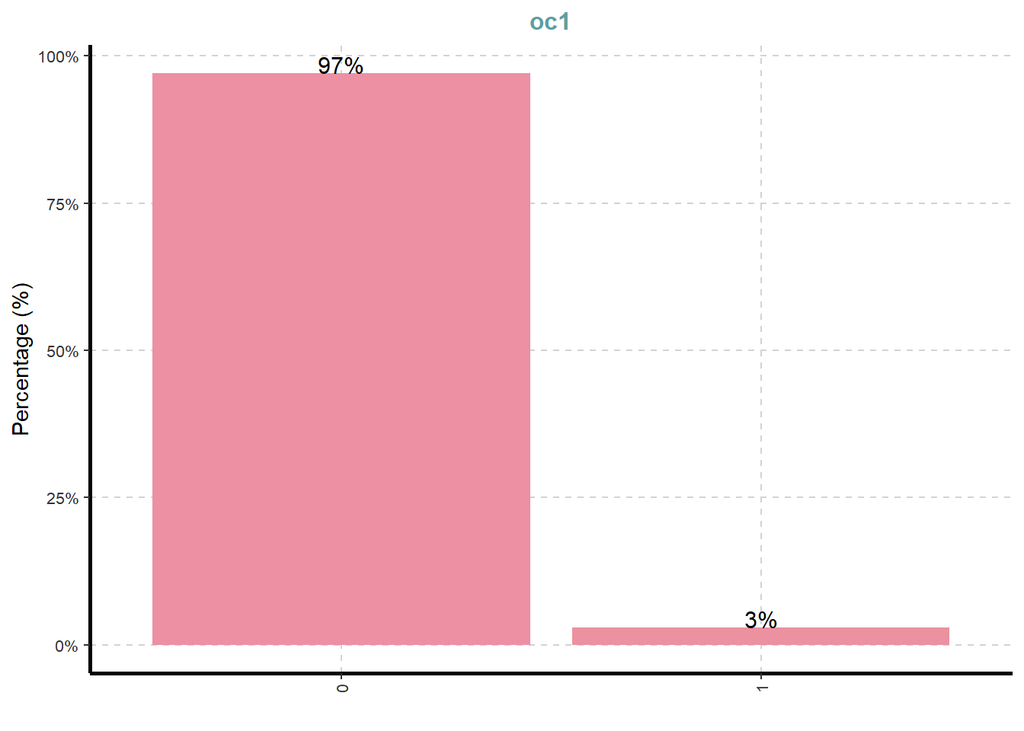

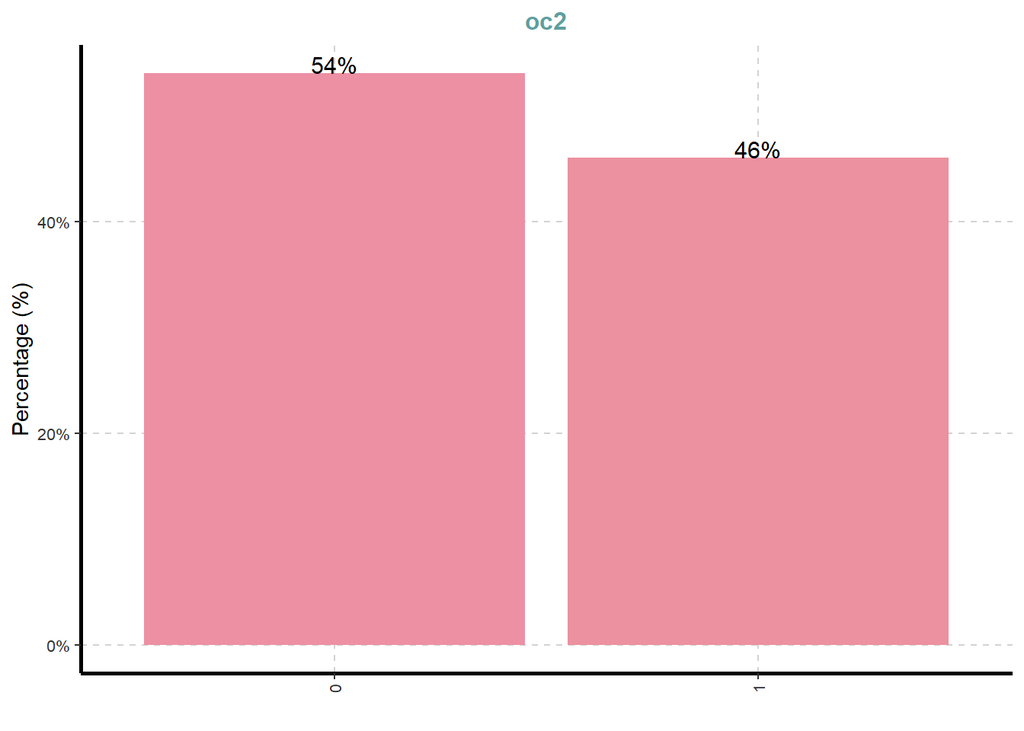

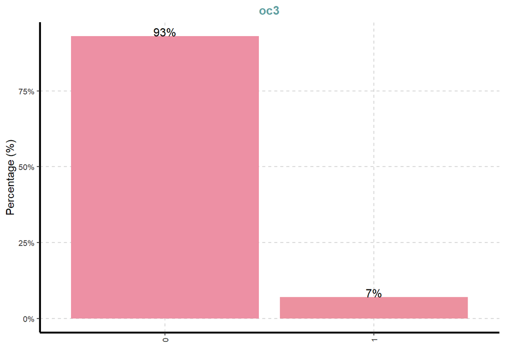

[10 more figures not shown]

```r
plot2 <- ExpCatViz(ds)
plot2
```

# 2. Estimation of Systematic Differnce between Size=8 and 9

```r
ds$Q <- as.numeric(ds$size==9)

r1 = lm(male~Q, data=ds)
r2 = lm(edu~Q, data=ds)
r3 = lm(mar~Q, data=ds)
r4 = lm(tenure~Q, data=ds)
r5 = lm(metro~Q, data=ds)
r6 = lm(non_regular~Q, data=ds)
r7 = lm(weektime~Q, data=ds)
r8 = lm(hourlywage~Q, data=ds)
r9 = lm(hourly_wage_r~Q, data=ds)

summary(r1)
```

```
##
## Call:
## lm(formula = male ~ Q, data = ds)
##
## Residuals:
##     Min      1Q  Median      3Q     Max
## -0.8394  0.1606  0.1606  0.2211  0.2211
##
## Coefficients:
##             Estimate Std. Error t value Pr(>|t|)
## (Intercept) 0.778876   0.003198  243.51   <2e-16 ***
## Q           0.060509   0.004476   13.52   <2e-16 ***
## ---
## Signif. codes:  0 '***' 0.001 '**' 0.01 '*' 0.05 '.' 0.1 ' ' 1
##
## Residual standard error: 0.3913 on 30582 degrees of freedom
## Multiple R-squared:  0.005939,   Adjusted R-squared:  0.005907
## F-statistic: 182.7 on 1 and 30582 DF,  p-value: < 2.2e-16
```

```r
summary(r2)
```

```
##
## Call:
## lm(formula = edu ~ Q, data = ds)
##
## Residuals:
##      Min       1Q   Median       3Q      Max
## -14.2100  -2.0903  -0.0903   1.9097   6.9097
##
## Coefficients:
##             Estimate Std. Error t value Pr(>|t|)
## (Intercept) 14.09025    0.02200 640.433  < 2e-16 ***
## Q            0.11974    0.03079   3.889 0.000101 ***
## ---
## Signif. codes:  0 '***' 0.001 '**' 0.01 '*' 0.05 '.' 0.1 ' ' 1
##
## Residual standard error: 2.692 on 30582 degrees of freedom
## Multiple R-squared:  0.0004942,  Adjusted R-squared:  0.0004616
## F-statistic: 15.12 on 1 and 30582 DF,  p-value: 0.000101
```

```r
summary(r3)
```

```
##
## Call:
## lm(formula = mar ~ Q, data = ds)
##
## Residuals:
##     Min      1Q  Median      3Q     Max
## -0.8096  0.1904  0.1904  0.2178  0.2178
##
## Coefficients:
##             Estimate Std. Error t value Pr(>|t|)
## (Intercept) 0.782217   0.003291 237.710  < 2e-16 ***
## Q           0.027390   0.004605   5.947 2.75e-09 ***
## ---
## Signif. codes:  0 '***' 0.001 '**' 0.01 '*' 0.05 '.' 0.1 ' ' 1
##
## Residual standard error: 0.4026 on 30582 degrees of freedom
## Multiple R-squared:  0.001155,   Adjusted R-squared:  0.001123
## F-statistic: 35.37 on 1 and 30582 DF,  p-value: 2.753e-09
```

```r
summary(r4)
```

```
##
## Call:
## lm(formula = tenure ~ Q, data = ds)
##
## Residuals:
##     Min      1Q  Median      3Q     Max
## -10.895  -6.156  -1.156   5.105  40.844
##
## Coefficients:
##             Estimate Std. Error t value Pr(>|t|)
## (Intercept)  9.15552    0.06297  145.40   <2e-16 ***
## Q            1.73952    0.08813   19.74   <2e-16 ***
## ---
## Signif. codes:  0 '***' 0.001 '**' 0.01 '*' 0.05 '.' 0.1 ' ' 1
##
## Residual standard error: 7.704 on 30582 degrees of freedom
## Multiple R-squared:  0.01258,    Adjusted R-squared:  0.01255
## F-statistic: 389.6 on 1 and 30582 DF,  p-value: < 2.2e-16
```

```r
summary(r5)
```

```
##
## Call:
## lm(formula = metro ~ Q, data = ds)
##
## Residuals:
##     Min      1Q  Median      3Q     Max
## -0.5662 -0.5374  0.4338  0.4626  0.4626
##
## Coefficients:
##             Estimate Std. Error t value Pr(>|t|)
## (Intercept) 0.537377   0.004063 132.264  < 2e-16 ***
## Q           0.028809   0.005686   5.067 4.07e-07 ***
## ---
## Signif. codes:  0 '***' 0.001 '**' 0.01 '*' 0.05 '.' 0.1 ' ' 1
##
## Residual standard error: 0.4971 on 30582 degrees of freedom
## Multiple R-squared:  0.0008387,  Adjusted R-squared:  0.000806
## F-statistic: 25.67 on 1 and 30582 DF,  p-value: 4.073e-07
```

```r
summary(r6)
```

```
##
## Call:
## lm(formula = non_regular ~ Q, data = ds)
##
## Residuals:
##      Min       1Q   Median       3Q      Max
## -0.10308 -0.10308 -0.07025 -0.07025  0.92975
##
## Coefficients:
##              Estimate Std. Error t value Pr(>|t|)
## (Intercept)  0.103080   0.002292   44.98   <2e-16 ***
## Q           -0.032827   0.003207  -10.24   <2e-16 ***
## ---
## Signif. codes:  0 '***' 0.001 '**' 0.01 '*' 0.05 '.' 0.1 ' ' 1
##
## Residual standard error: 0.2804 on 30582 degrees of freedom
## Multiple R-squared:  0.003414,   Adjusted R-squared:  0.003382
## F-statistic: 104.8 on 1 and 30582 DF,  p-value: < 2.2e-16
```

```r
summary(r7)
```

```
##
## Call:
## lm(formula = weektime ~ Q, data = ds)
##
## Residuals:
##     Min      1Q  Median      3Q     Max
## -18.288  -9.516  -2.288   4.712  90.484
##
## Coefficients:
##             Estimate Std. Error t value Pr(>|t|)
## (Intercept) 50.28826    0.09658  520.68  < 2e-16 ***
## Q           -0.77184    0.13517   -5.71 1.14e-08 ***
## ---
## Signif. codes:  0 '***' 0.001 '**' 0.01 '*' 0.05 '.' 0.1 ' ' 1
##
## Residual standard error: 11.82 on 30582 degrees of freedom
## Multiple R-squared:  0.001065,   Adjusted R-squared:  0.001032
## F-statistic: 32.61 on 1 and 30582 DF,  p-value: 1.139e-08
```

```r
summary(r8)
```

```
##
## Call:
## lm(formula = hourlywage ~ Q, data = ds)
##
## Residuals:
##    Min     1Q Median     3Q    Max
## -1.397 -0.397 -0.190  0.603 38.810
##
## Coefficients:
##             Estimate Std. Error t value Pr(>|t|)
## (Intercept) 1.190059   0.007296  163.12   <2e-16 ***
## Q           0.207187   0.010210   20.29   <2e-16 ***
## ---
## Signif. codes:  0 '***' 0.001 '**' 0.01 '*' 0.05 '.' 0.1 ' ' 1
##
## Residual standard error: 0.8926 on 30582 degrees of freedom
## Multiple R-squared:  0.01329,    Adjusted R-squared:  0.01325
## F-statistic: 411.8 on 1 and 30582 DF,  p-value: < 2.2e-16
```

```r
summary(r9)
```

```
##
## Call:
## lm(formula = hourly_wage_r ~ Q, data = ds)
##
## Residuals:
##    Min     1Q Median     3Q    Max
## -1.661 -0.661 -0.423  0.577 50.577
##
## Coefficients:
##             Estimate Std. Error t value Pr(>|t|)
## (Intercept) 1.423208   0.008349  170.47   <2e-16 ***
## Q           0.238271   0.011684   20.39   <2e-16 ***
## ---
## Signif. codes:  0 '***' 0.001 '**' 0.01 '*' 0.05 '.' 0.1 ' ' 1
##
## Residual standard error: 1.021 on 30582 degrees of freedom
## Multiple R-squared:  0.01342,    Adjusted R-squared:  0.01338
## F-statistic: 415.9 on 1 and 30582 DF,  p-value: < 2.2e-16
```

# 3. Introduction to DD(Differnce in Differnce)

DD(이중차분법)의 기본 가정은 정책 변화 전의 처리 그룹(treatment)과 통제 그룹(control)의 추세(trend)가 일정해야 한다는 것이다. 예를 들어 t=-2 시기의 두 그룹의 임금 격차가 t=-1 시기나 t=0 시기에도 비슷하게 유지되어야 t=1 시기의 임금 변화가 처리 효과로서 유의미하다는 의미이다.

```r
ds$y1 = ds$weektime
ds$y2 = ds$hourly_wage_r
ds$y3 = ds$y1*ds$y2

ds$t02 = as.numeric(ds$year==2002)
ds$t03 = as.numeric(ds$year==2003)
ds$t04 = as.numeric(ds$year==2004)
ds$t05 = as.numeric(ds$year==2005)
ds$t06 = as.numeric(ds$year==2006)
```

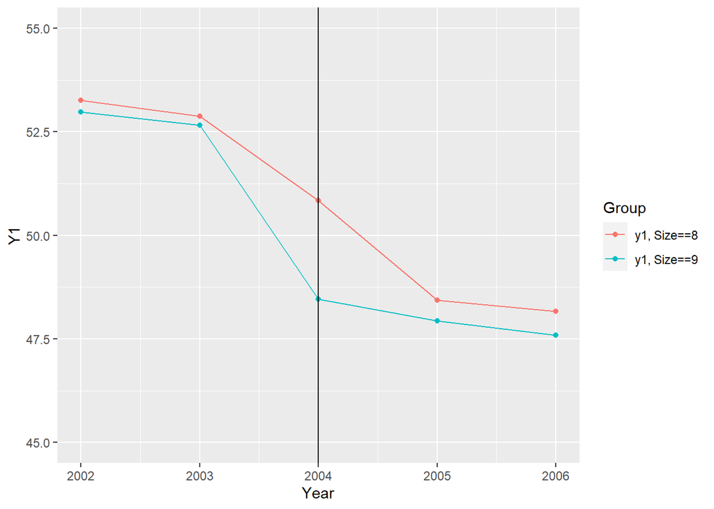

```r
minfo_y1 = aggregate(ds$y1, list(ds$year,ds$Q == 1), mean)
names(minfo_y1) = c("YR","Treatment","y1")

minfo_y1$Group[1:5] = "y1, Size==8"
minfo_y1$Group[6:10] = "y1, Size==9"

qplot(YR, y1, data=minfo_y1, geom=c("point","line"), colour=Group,
      xlab="Year", ylab="Y1",
      ylim=c(45, 55)) + geom_vline(xintercept = 2004)
```

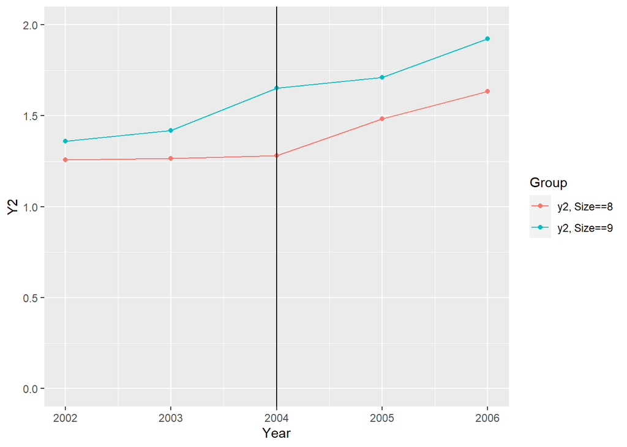

```r
minfo_y2 = aggregate(ds$y2, list(ds$year,ds$Q == 1), mean)
names(minfo_y2) = c("YR","Treatment","y2")

minfo_y2$Group[1:5] = "y2, Size==8"
minfo_y2$Group[6:10] = "y2, Size==9"

qplot(YR, y2, data=minfo_y2, geom=c("point","line"), colour=Group,
      xlab="Year", ylab="Y2",
      ylim=c(0, 2)) + geom_vline(xintercept = 2004)
```

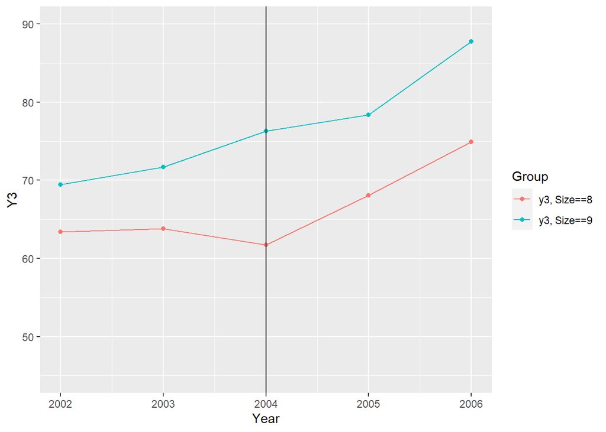

```r
minfo_y3 = aggregate(ds$y3, list(ds$year,ds$Q == 1), mean)
names(minfo_y3) = c("YR","Treatment","y3")

minfo_y3$Group[1:5] = "y3, Size==8"
minfo_y3$Group[6:10] = "y3, Size==9"

qplot(YR, y3, data=minfo_y3, geom=c("point","line"), colour=Group,
      xlab="Year", ylab="Y3",
      ylim=c(45, 90)) + geom_vline(xintercept = 2004)
```